# Mapping and Spatial Analysis for Hydrologic Data

PNW Tribal Coding Retreat

Marc Weber

EPA (USA)

2025-03-18

## Details

1. Please visit https://mhweber.github.io/PNW-Tribal-Coding-Retreat/ to view the workshop’s accompanying workbook
2. Install and load R packages by visiting “Setup” in the workbook’s “Welcome” section
3. (Optional) Download the workshop slides (instructions in the workbook’s “Welcome” section)
4. Follow along and enjoy!

## Who Am I?

I’m a geographer at the Pacific Ecological Systems Division (PESD) at the United States Environmental Protection Agency (USEPA). My work supports various aspects of the USEPA’s National Aquatic Resource Surveys (NARS), which characterize the condition of waters across the United States, and I help to develop and maintain the [StreamCat](https://www.epa.gov/national-aquatic-resource-surveys/streamcat-dataset) and [LakeCat](https://www.epa.gov/national-aquatic-resource-surveys/lakecat-dataset) datasets. My work focuses on spatial analysis in R and Python, Geographic Information Science (GIS), aquatic ecology, remote sensing, open source science and environmental modeling.

## Disclaimer

The views expressed in this workshop are those of the authors and do not necessarily represent the views or policies of the U.S. Environmental Protection Agency or the U.S. National Oceanic and Atmospheric Administration. Any mention of trade names, products, or services does not imply an endorsement by the U.S. government, the U.S. Environmental Protection Agency, or the U.S. National Oceanic and Atmospheric Administration. The U.S. Environmental Protection Agency and the U.S. National Oceanic and Atmospheric Administration do not endorse any commercial products, services, or enterprises.

## What Will We Cover?

- Foundations of spatial data
- Geoprocessing spatial data
- Mapping tools in R
- Web Services for Hydrologic Applications

# Foundations

## Goals

1. Understand fundamental spatial data structures and libraries in **R**.
2. Become familiar with coordinate reference systems.
3. Geographic I/O (input/output).

## Data Structures

- Review data structures section in workbook
- Cover vectors, matrices, arrays, lists, data frames, etc.
- Cover data frame manipulation using [tidyverse](https://www.tidyverse.org/) functions and the pipe operator (`%>%` or `|>`)

## Why R for Spatial Data Analysis?

- Lightweight, open-source, and cross-platform
- Provides tools for automation and reproducibility
- Seamlessly integrates spatial data analysis and statistical analysis in one environment
- Handles vector and raster data

## R Drawbacks for GIS Work

- R is less interactive than desktop applications like ArcGIS or QGIS
- Handling coordinate reference systems is more challenging
- In-memory analysis can be prohibitive for large data
- Steep learning curve

## A Motivating Example

- Simple, expressive code

```r
library(tmap)
library(tmaptools)
library(dplyr)

# find my town!
my_town <- tmaptools::geocode_OSM("Corvallis OR USA", as.sf = TRUE)
glimpse(my_town)
```

```
Rows: 1
Columns: 9
$ query   <chr> "Corvallis OR USA"
$ lat     <dbl> 44.56457
$ lon     <dbl> -123.262
$ lat_min <dbl> 44.51993
$ lat_max <dbl> 44.60724
$ lon_min <dbl> -123.3362
$ lon_max <dbl> -123.231
$ bbox    <POLYGON [°]> POLYGON ((-123.3362 44.5199...
$ point   <POINT [°]> POINT (-123.262 44.56457)
```

## Your Turn

1. What does `::` do?
2. What does `geocode_OSM()` do?
3. Explain how the code runs together using the `|>` chaining operator
4. What is `glimpse()`? How is it useful compared to `head()`?

`05:00`

## Our Turn

1. `::` lets you clarify from which package a function is called (e.g., `tmaptools::geocodeOSM()`)
2. `geocode_OSM()` looks up a named feature in OpenStreetMap and returns the coordinates
3. Do this `|>` then that
4. `glimpse()` glimpses at a data frame

## A Choropleth Map

- A choropleth map is a map that connects statistical summaries to geographic characteristics
- The `tigris` package can retrieve census, county, and state boundaries as vector `sf` data

```r
library(tigris)
library(sf)
counties <- counties("Oregon", cb = TRUE)
counties$area <- as.numeric(st_area(counties))
glimpse(counties)

tm_shape(counties) +
  tm_polygons("area", style="quantile", title="Area of Oregon Counties")
```

## A Choropleth Map

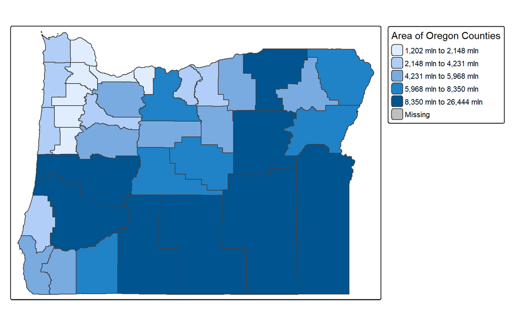

Figure 1: Distribution of Oregon counties.

## Your Turn

Create and explore an interactive map of `my_town` by running

```r
library(mapview)
mapviewOptions(fgb=FALSE)
mapview(my_town, col="red", col.regions = "red") +
  mapview(counties, alpha.regions = .1)
```

`04:00`

## Our Turn

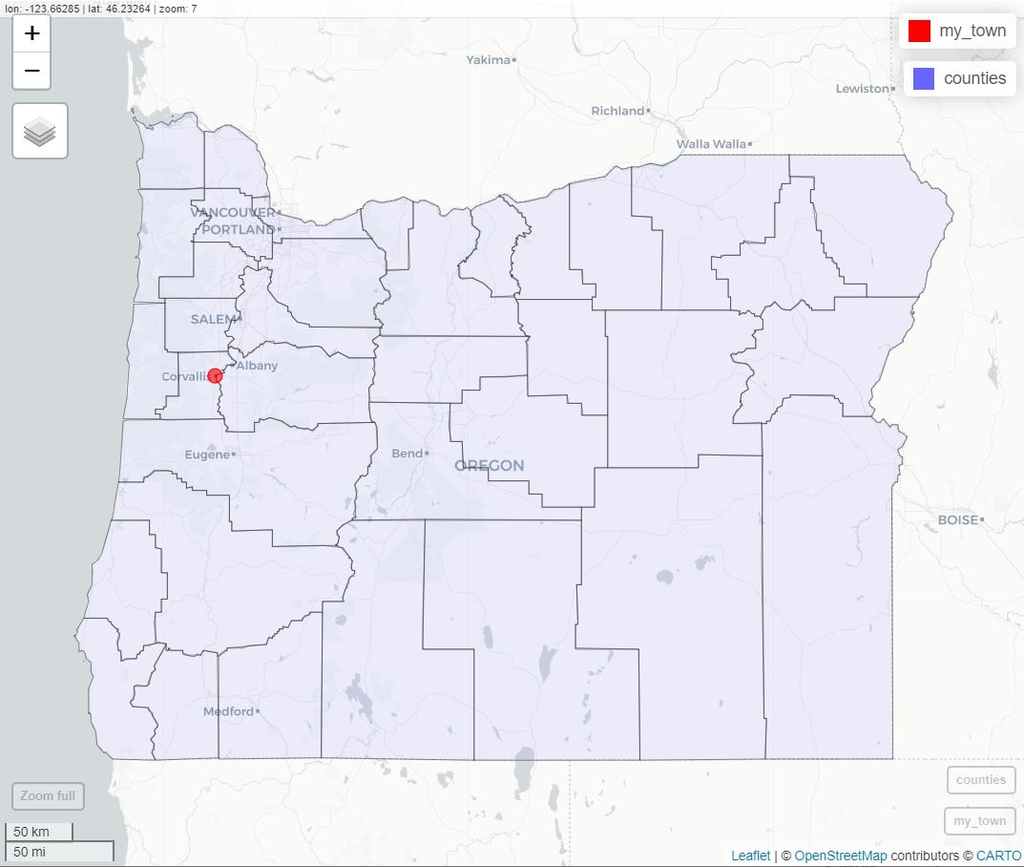

Figure 2: Corvallis among distribution of Oregon counties.

## Spatial Data Structures

- Spatial data structures are primarily organized through:
1. GDAL [link here](https://gdal.org/): For raster and feature abstraction and processing
2. PROJ [link here](https://proj.org/): For coordinate transformations and projections
3. GEOS [link here](https://libgeos.org/): For spatial operations (e.g., calculating buffers or centroids) on data with a projected coordinate reference system (CRS)
- We explore these core libraries throughout the workshop

## Types of Spatial Data

- Vector data are comprised of points, lines, and polygons that represent discrete spatial entities (e.g., river, wtaershed, stream gauge)
- Raster data divide space into small rectangles (pixels) that represent spatially continuous phenomena like elevation or precipitation

## Types of Spatial Data

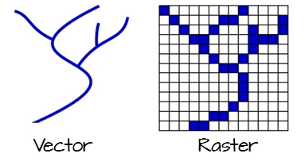

Figure 3: Vector and raster data.

## Vector Data Model

- Vector data are described using simple features
- Simple features is a standard way to specify how two-dimensional geometries are represented, stored in and retrieved from databases, and which geometric operations can be performed
- Provides framework for extending spatial `POINTS` to `LINES` and `POLYGONS`

## Types of Spatial Data

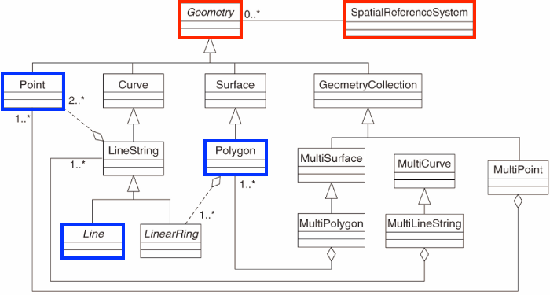

Figure 4: The simple features data model.

## The `sf` Package

- We use the `sf` package to work with spatial vector data in **R**
- Learn more about `sf` at their website r-spatial.github.io/sf and/or by running

```r
vignette(package = "sf") # see which vignettes are available
vignette("sf1")          # open the introduction vignette
```

## `sf` Primitives

- There are three basic `geometric` primitives with corresponding `sf` functions to create them:
1. `POINT`: created with `st_points()`
2. `LINESTRING`: created with `st_linestring()`
3. `POLYGON`: created with `st_polygon()`
- More complex simple feature geometries are built up using `st_multipoint()`, `st_multilinestring()`, `st_multipolygon()`, and `st_geometrycollection()`
- Building blocks for more complicated/large data structures

## `POINT`s

- Points in `sf` are composed of coordinate pairs and a coordinate reference system
- Points have no length or area

```r
# create sf object as point
pt1 <- st_point(c(1,3))
pt2 <- st_point(c(2,1))
pt3 <- st_point(c(3,2))
sf_point <- st_sfc(pt1, pt2, pt3)
```

```r
library(ggplot2)
ggplot(sf_point) +
  geom_sf(color = "red") +
  labs(x = "X", y = "Y")
```

## `POINT`s

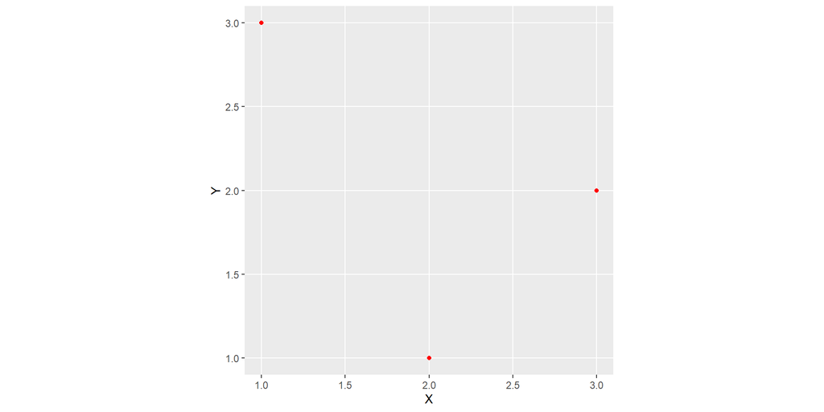

Figure 5: sf `POINT`

## `LINESTRING`s

- An ordered sequence of two or more `POINT`s
- Points in a line are called verticies (or nodes)
- Linestrings have length but no area

```r
# create sf object as linestring
line1 <- sf::st_linestring(rbind(pt1, pt2))
line2 <- sf::st_linestring(rbind(pt2, pt3))
sf_linestring <- st_sfc(line1, line2)
```

```r
ggplot(sf_linestring) +
  geom_sf() +
  labs(x = "X", y = "Y")
```

## `LINESTRING`s

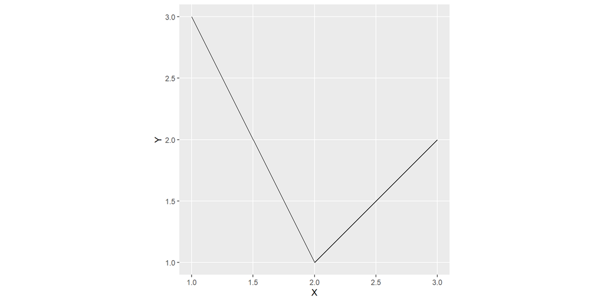

Figure 6: sf `LINESTRING`

## `POLYGON`s

- Four or more points with the same starting and ending point
- Has length and area

```r
pt4 <- pt1
poly1 <- st_polygon(list(rbind(pt1, pt2, pt3, pt4)))
sf_polygon <- st_sfc(poly1)

# dimension
sf::st_dimension(sf_polygon)
```

```
[1] 2
```

```r
ggplot(sf_polygon) +
  geom_sf(fill = "grey")
```

## `POLYGON`s

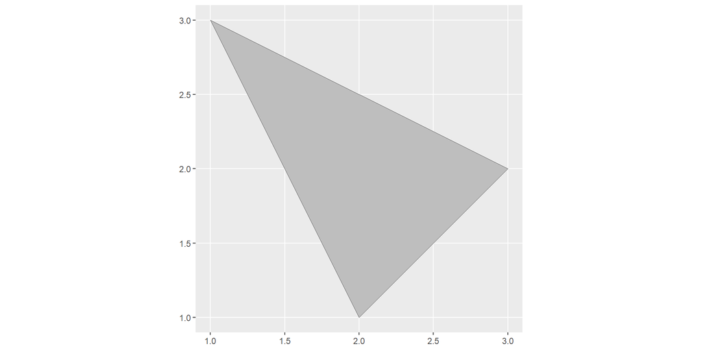

Figure 7: sf `POLYGON`

## Putting Them All Together

```r
ggplot() +
  geom_sf(data = sf_point, color = "red") +
  geom_sf(data = sf_linestring) +
  geom_sf(data = sf_polygon, fill = "grey")
```

## Putting Them All Together

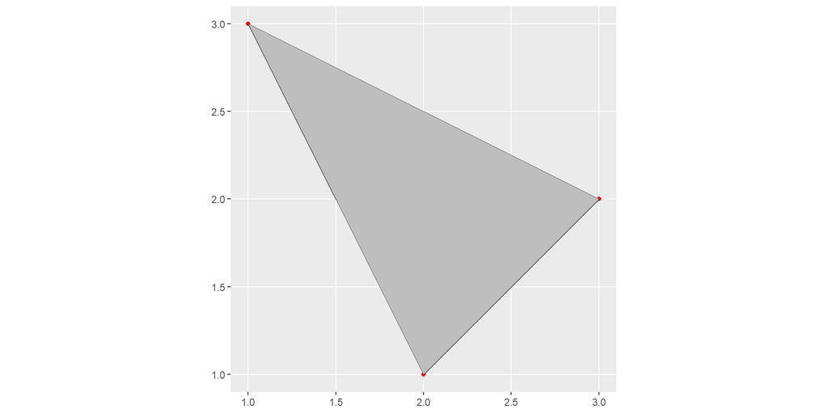

Figure 8: sf `POINT`, `LINESTRING`, and `POLYGON` overlain

## Spatial Data Frames

- `sf` objects combine `data.frame` attributes with `POINT`, `LINESTRING`, and `POLYGON` building blocks (these are the `geometry`)
- Also characterize dimensionality, bounding box, coordinate reference system, attribute headers
- Read from shapefiles using `st_read()` or `read_sf()`

```r
library(spData)
data("us_states")
print(us_states)
```

## Spatial Data Frames

```
Simple feature collection with 49 features and 6 fields
Geometry type: MULTIPOLYGON
Dimension:     XY
Bounding box:  xmin: -124.7042 ymin: 24.55868 xmax: -66.9824 ymax: 49.38436
Geodetic CRS:  NAD83
First 10 features:
   GEOID        NAME   REGION             AREA total_pop_10 total_pop_15
1     01     Alabama    South 133709.27 [km^2]      4712651      4830620
2     04     Arizona     West 295281.25 [km^2]      6246816      6641928
3     08    Colorado     West 269573.06 [km^2]      4887061      5278906
4     09 Connecticut Norteast  12976.59 [km^2]      3545837      3593222
5     12     Florida    South 151052.01 [km^2]     18511620     19645772
6     13     Georgia    South 152725.21 [km^2]      9468815     10006693
7     16       Idaho     West 216512.66 [km^2]      1526797      1616547
8     18     Indiana  Midwest  93648.40 [km^2]      6417398      6568645
9     20      Kansas  Midwest 213037.08 [km^2]      2809329      2892987
10    22   Louisiana    South 122345.76 [km^2]      4429940      4625253
                         geometry
1  MULTIPOLYGON (((-88.20006 3...
2  MULTIPOLYGON (((-114.7196 3...
3  MULTIPOLYGON (((-109.0501 4...
4  MULTIPOLYGON (((-73.48731 4...
5  MULTIPOLYGON (((-81.81169 2...
6  MULTIPOLYGON (((-85.60516 3...
7  MULTIPOLYGON (((-116.916 45...
8  MULTIPOLYGON (((-87.52404 4...
9  MULTIPOLYGON (((-102.0517 4...
10 MULTIPOLYGON (((-92.01783 2...
```

## Your Turn

So far we have explored plotting using `ggplot()`, but you can also use `sf`’s base plotting via `plot()`. Read more about plotting in `sf` by running `?plot.sf` and then make an appropriate plot of the `us_states` data.

`05:00`

## Our Turn

Running `plot()` in `sf` plots all variables; common to subset

```r
plot(us_states["AREA"])
```

## Our Turn

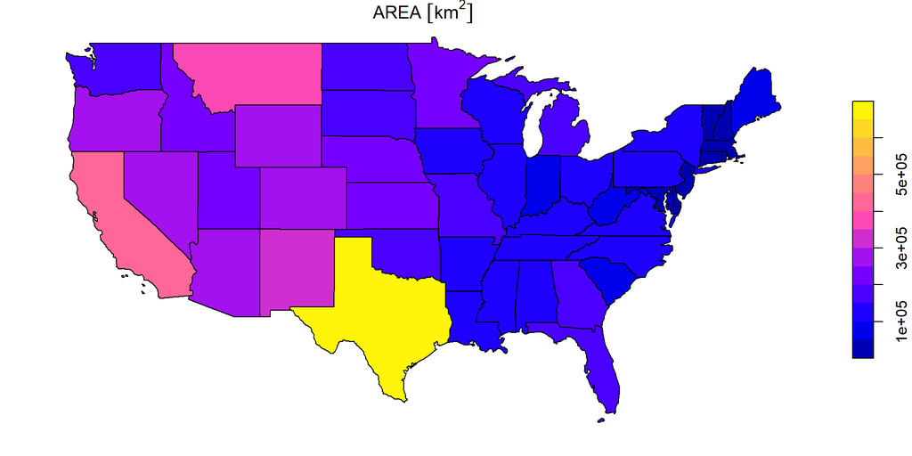

Figure 10: Area by state in the US.

## Raster Data Model

- Raster data can be continuous or categorical
- Can be image based; have a temporal component

## Raster Data Model

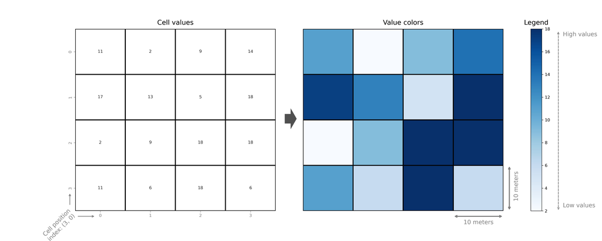

Figure 11: The raster data model.

## The `terra` Package

- We use the `terra` package to work with spatial raster data in **R**
- `terra` is the modern replacement to `raster`
- Learn more about `terra` at their website https://rspatial.org/
- `stars` for spatio-temporal rasters

## Creating a Raster Object

- Create an empty `SpatRaster` object; define rows, columns, bounding box

```r
library(terra)
myrast <- rast(ncol = 10, nrow = 10, xmax = -116, xmin = -126, ymin = 42, ymax = 46)
str(myrast)
```

```
S4 class 'SpatRaster' [package "terra"]
```

```r
print(myrast)
```

```
class       : SpatRaster
dimensions  : 10, 10, 1  (nrow, ncol, nlyr)
resolution  : 1, 0.4  (x, y)
extent      : -126, -116, 42, 46  (xmin, xmax, ymin, ymax)
coord. ref. : lon/lat WGS 84 (CRS84) (OGC:CRS84)
```

## Your Turn

We just printed `myrast` and saw several components: `class`, `dimensions`, `resolution`, `extent`, and `coord. ref`. Explicitly return and inspect each of these pieces using `class()`, `ncell()`, `res()`, `ext()`, and `crs()`. Bonus: Return the number of raster cells using `ncell()`.

`05:00`

## Our Turn

```r
class(myrast)
```

```
[1] "SpatRaster"
attr(,"package")
[1] "terra"
```

```r
ncell(myrast)
```

```
[1] 100
```

```r
res(myrast)
```

```
[1] 1.0 0.4
```

```r
ext(myrast)
```

```
SpatExtent : -126, -116, 42, 46 (xmin, xmax, ymin, ymax)
```

```r
crs(myrast)
```

```
[1] "GEOGCRS[\"WGS 84 (CRS84)\",\n    DATUM[\"World Geodetic System 1984\",\n        ELLIPSOID[\"WGS 84\",6378137,298.257223563,\n            LENGTHUNIT[\"metre\",1]]],\n    PRIMEM[\"Greenwich\",0,\n        ANGLEUNIT[\"degree\",0.0174532925199433]],\n    CS[ellipsoidal,2],\n        AXIS[\"geodetic l…
```

```r
ncell(myrast)
```

```
[1] 100
```

## Manipulating Raster Objects

- Let’s add values to the raster object

```r
values(myrast) <- 1:ncell(myrast)
```

```r
plot(myrast)
```

## Manipulating Raster Objects

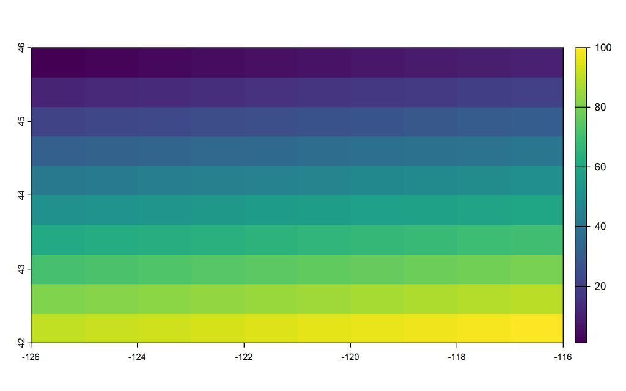

Figure 12: Raster plot.

## Reading a Raster Object

- Lets read in a raster object from the `spDataLarge` package that contains elevation data from Zion National Park

```r
raster_filepath <- system.file("raster/srtm.tif", package = "spDataLarge")
my_rast <- rast(raster_filepath)
```

```r
plot(my_rast)
```

## Reading a Raster Object

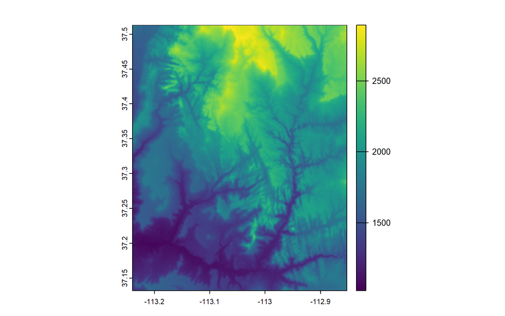

Figure 13: Raster plot of elevation from Zion National Park.

## Your Turn

The `spatRaster` object in `terra` can hold multiple layers. Read in the four bands of Landsat 8 data from Zion National Park by running

```r
landsat <- system.file("raster/landsat.tif", package = "spDataLarge")
landsat <- rast(landsat)
```

Then plot this raster using `plot()`.

`03:00`

## Our Turn

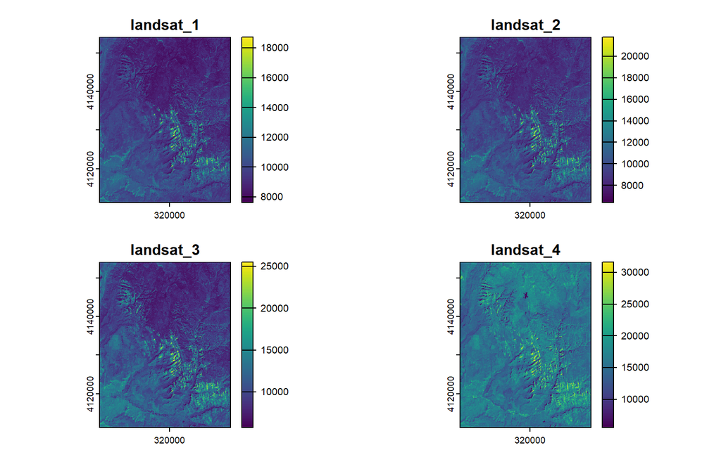

Figure 14: Raster plot of Landsat 8 data from Zion National Park.

```r
plot(landsat)
```

## Spatio-Temporal Raster Objects

- The `stars` package has tools for spatio-temporal raster data
- `stars` integrates with `sf` (recall that `terra` does not)
- Learn more at their website https://r-spatial.github.io/stars/

## Coordinate Reference Systems

A coordinate reference system (CRS) is made up of several components

1. Coordinate system: The x,y grid that defines where your data lies in space
2. Horizontal and vertical units: The units that describe the coordinate system
3. Datum: The modeled version of the earth’s shape
4. Projection details (if applicable): The mathematical equation used to flatten objects from round surface (earth) to flat surface (paper or screen)

## The Ellipsoid and Geoid

- The earth can be thought of as an ellipsoid defined by a semi-major (equatorial) axis and a semi-minor (polar) axis
- More precisely, it is a geoid that is not perfectly smooth
- A datum is built on top of the ellipsoid and incorporates local features
- The most appropriate datum depends on the location of interest (in the US we typically use NAD83)

## The Ellipsoid and Geoid

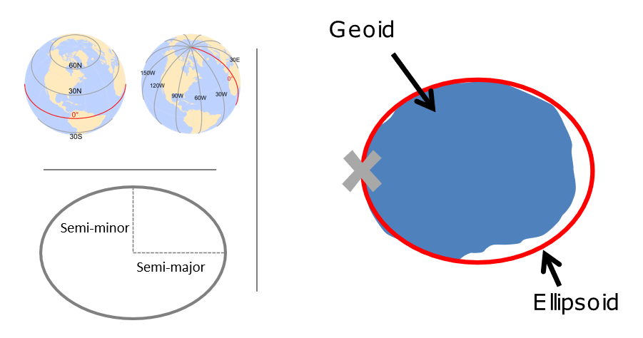

Figure 15: The ellipsoid and geoid.

## Your Turn

There are several websites that are helpful for learning more about specific coordinate reference systems

1. Spatial Reference: https://spatialreference.org/
2. Projection Wizard: https://projectionwizard.org/
3. EPSG: https://epsg.io/

Spend a few minutes learning about one or more of these references by visiting their websites.

`04:00`

## Specifying a CRS

There are many ways to specify a CRS:

1. Proj4
   - `+proj = longlat + ellps=WGS84 ...`
2. OGC WKT / ESRI WKT
   - `GEOGCS["WGS 84", DATUM["WGS_1984, SPHERIOD["WGS 84 ...]]]`
3. authority:code identifier (modern/preferred)
   - `EPSG: 4326`

## Projected Coordinate Systems

- Projected coordinates have been projected to two-dimensional space according to a CRS
- Projected coordinates have an origin, x-axis, y-axis, and unit of measure
- Conformal projections preserve shape
- Equal-area projections preserve area
- Equidistant projections preserve distance
- Azimuthal projection preserves direction

## Projected Coordinate Systems

- Here an example using vector data; see the workbook for an example using raster data

```r
library(Rspatialworkshop)
data("pnw")
# transform one to the other
utmz11 <- 2153
pnw <- st_transform(pnw, crs = utmz11)
ggplot() +
  geom_sf(data = pnw,  color="black", fill=NA) +
  labs(title="State Boundaries in the Pacific Northwest") +
  theme_bw()
```

## Projected Coordinate Systems

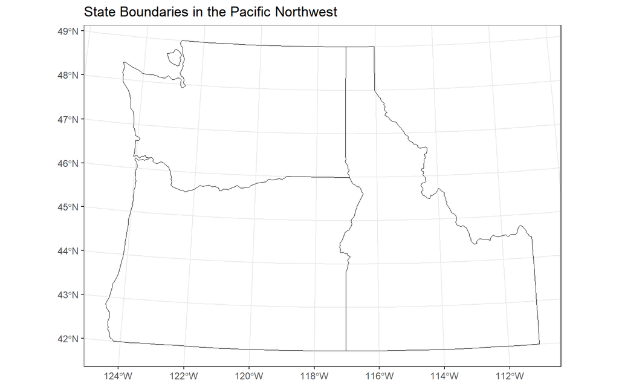

Figure 16: PNW State Boundaries.

## Your Turn

Re-project the `pnw` data to a different projected CRS. Then plot using base **R** or `ggplot2`.

`04:00`

## Our Turn

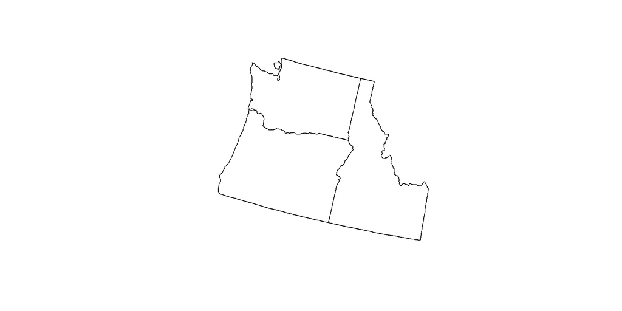

```r
pnw2 <- st_transform(pnw, crs = 5070)
plot(st_geometry(pnw2))
```

## A Note on `S2`

- `sf` version `1.0.0` supports spherical geometry operations via its interface to Google’s `S2` spherical geometry engine
- `S2` is an example of a Discrete Global Grid System (DGGS)
- `sf` can run with `s2` on or off and by default the S2 geometry engine is turned on:

```r
sf::sf_use_s2()
```

## Geographic Data I/O (Input/Ouptut)

There are several ways to read spatial data into R

1. Load spatial data from our machine or a remote source
2. Load spatial data as part of an **R** package
3. Load data using an API (which often makes use of an **R** package)
4. Convert flat files with x, y coordinates to spatial data
5. Geocoding data “by-hand” (we saw this earlier)

## Vector Data I/O

`sf` can read numerous file types:

1. shapefiles
2. geodatabases
3. geopackages
4. geojson
5. spatial database files

## Read in a Shapefile

```r
filepath <- system.file("extdata/city_limits.shp", package = "Rspatialworkshop")
citylims <- read_sf(filepath)
plot(st_geometry(citylims), axes = T, main = "Oregon City Limits")
```

## Read in a Shapefile

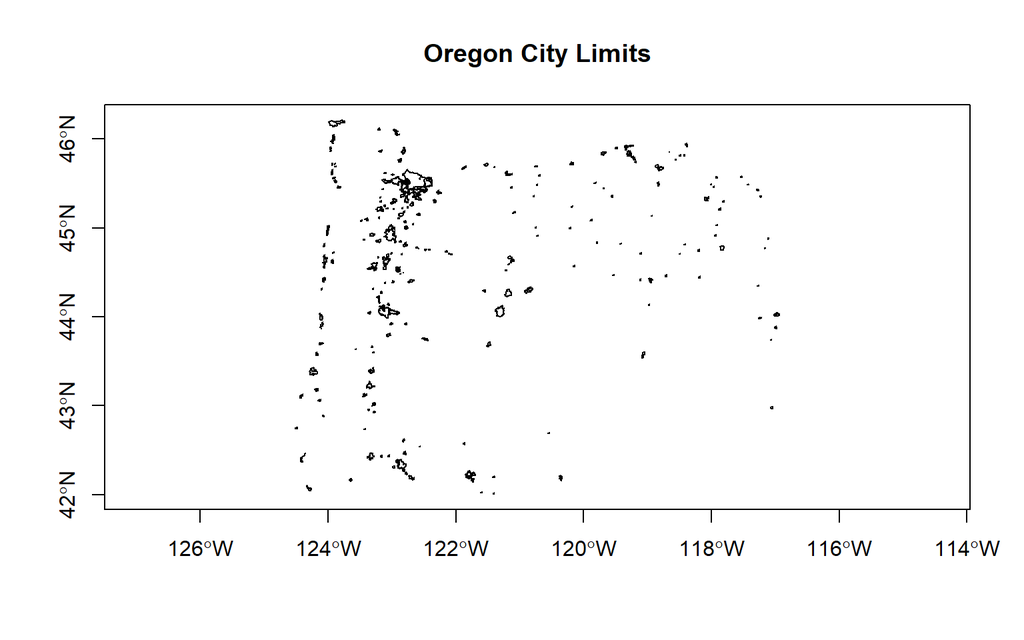

Figure 17: Oregon City Limits

## Your Turn

Run `?read_sf()` and compare `read_sf()` to `st_read()`. Our preference is to use `read_sf()` – why do you think that is?

`03:00`

## Our Turn

`read_sf()` calls `st_read()` with defaults chosen:

- `stringsAsFactors = FALSE`
- `quiet = TRUE`
- `as_tibble = TRUE`

## Read in a Geodatabase

```r
filepath <- system.file("extdata/StateParkBoundaries.gdb", package = "Rspatialworkshop")
# List all feature classes in a file geodatabase
st_layers(filepath)
# Read the feature class
parks <- st_read(dsn = filepath, layer="StateParkBoundaries")
ggplot(parks) +
  geom_sf()
```

## Read in a Geodatabase

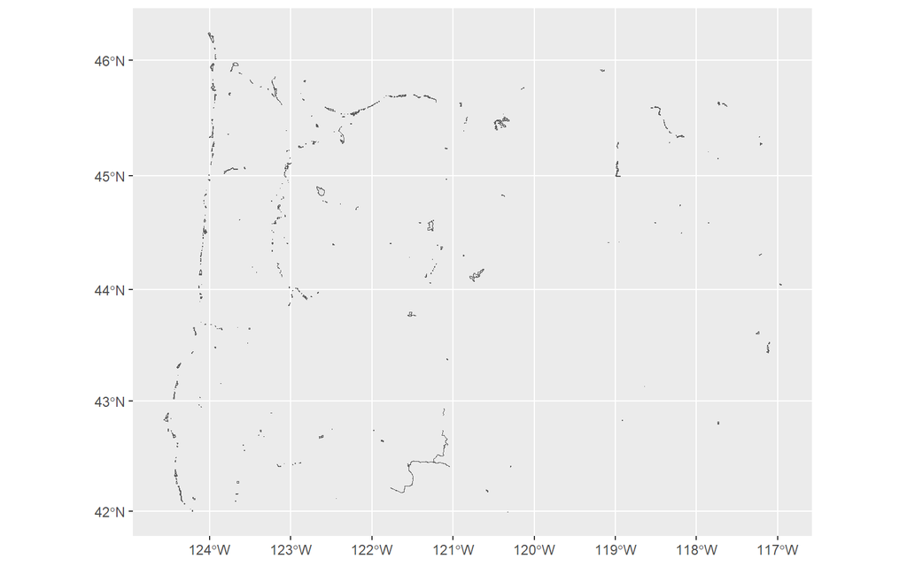

Figure 18: State Park Boundaries

## Read in a Geopackage

```r
filepath <- system.file("gpkg/nc.gpkg", package="sf")
nc <- read_sf(filepath)
ggplot(nc) +
  geom_sf()
```

## Read in a Geopackage

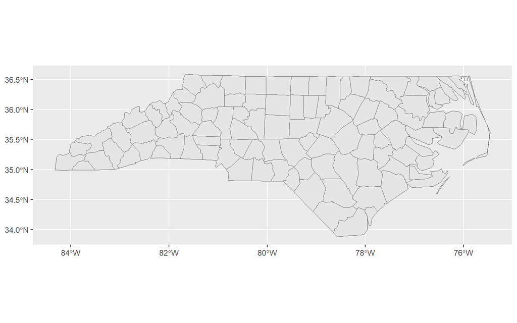

Figure 19: North Carolina Counties

## Geopackage Advantages

Why use geopackages over shapefiles?

1. Geopackages avoid mult-file format of shapefiles
2. Geopackages avoid the 2gb limit of shapefiles
3. Geopackages are open-source and follow OGC standards
4. Geopackages are lighter in file size than shapefiles
5. Geopackages avoid the 10-character limit to column headers in shapefile attribute tables (stored in archaic `.dbf` files)

## Other Approaches

The workbook shows how to read in data using

1. Open spatial data sources
2. **R** packages
3. OpenStreetMap

## Raster Data I/O

- Read in data using `rast()`

```r
filepath <- system.file("ex/elev.tif", package="terra")
elev <- rast(filepath)
barplot(elev, digits = -1, las = 2, ylab = "Frequency")
```

## Raster Data I/O

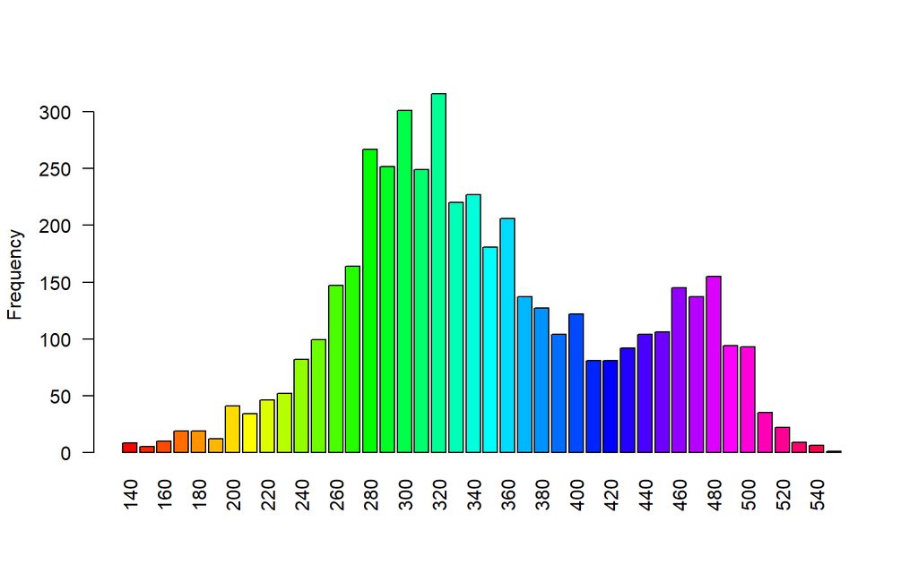

Figure 20: Elevation Data Barplot

## Raster Data I/O

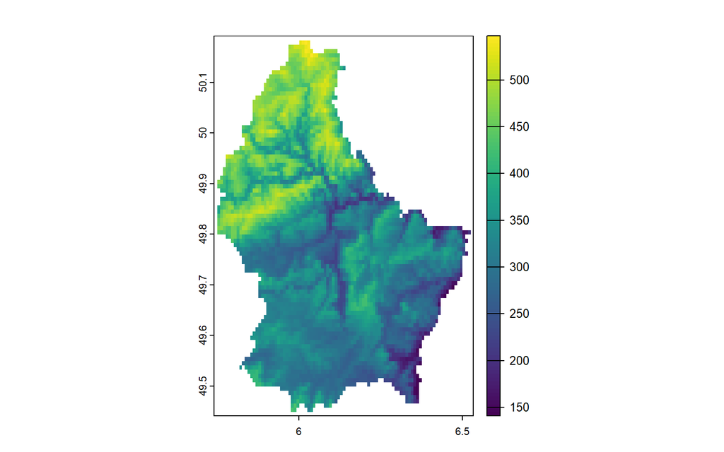

Figure 21: Elevation Data

```r
plot(elev)
```

## Raster Data I/O

```r
library(stars)
filepath <- system.file("tif/L7_ETMs.tif", package = "stars")
L7 <- read_stars(filepath) |>
  slice(index = 1, along = "band")
plot(L7)
```

## Raster Data I/O

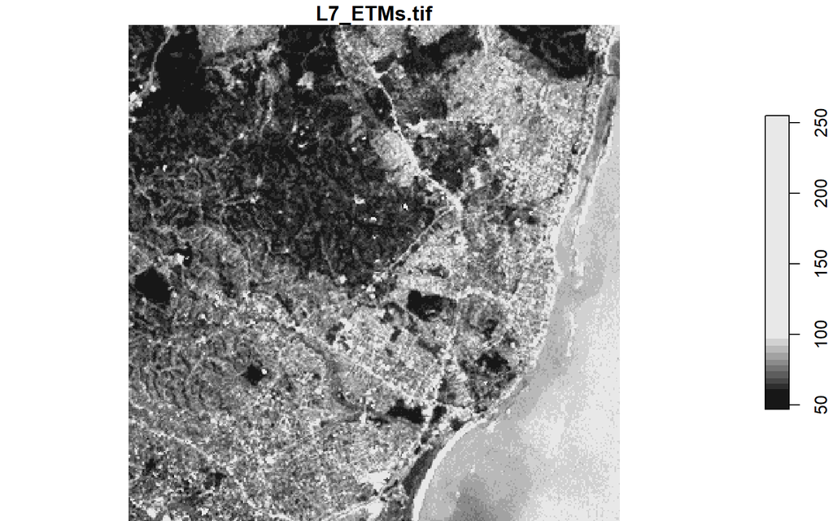

Figure 22: Landsat 7

## Convert Flat Files to Spatial

It is common for a flat file (e.g., a `.csv`) to have columns that indicate coordinates – how do we turn this into a spatial vector object?

```r
filepath <- system.file("extdata/Gages_flowdata.csv", package = "Rspatialworkshop")
gages <- read.csv(filepath)
gages_sf <- gages |>
  st_as_sf(coords = c("LON_SITE", "LAT_SITE"), crs = 4269, remove = FALSE)
ggplot(data = gages_sf) +
  geom_sf()
```

## Convert Flat Files to Spatial

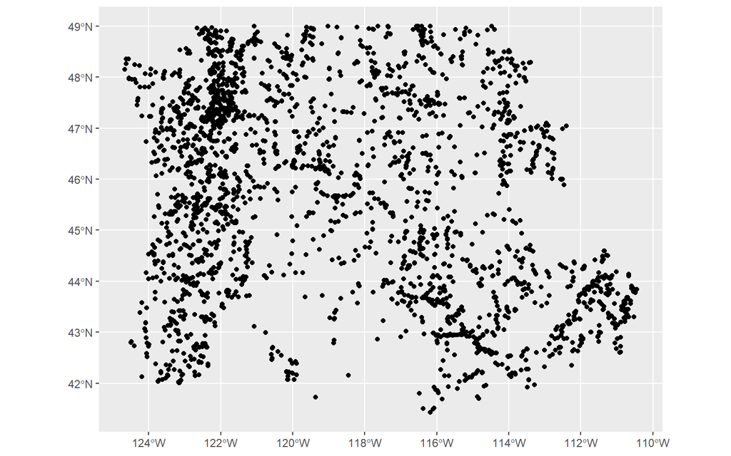

Figure 23: Stream Gages From a Flat File

# Visualization

## Goals

- Gain familiarity with plotting and visualizing spatial data in R
- Work with four specific visualization and plotting libraries:
  - `ggplot2`
  - `leaflet`
  - `mapview`
  - `tmap`

## Some Advice

Some advice from Martin Tennekes:

- If you know some `ggplot`, don’t care about interactive maps, and don’t want to spend a lot of time learning new packages, use `ggplot`
- If you want interactive maps as flexible as possible, use `leaflet`
- If you want to simply explore spatial objects ineractively as easily as possible, use `mapview`
- Otherwise, use `tmap`!

Projections are important!

## `ggplot2`

`ggplot2` now supports `geom_sf()`, developed alongside `sf` for pulication quality figures that easily incorporate projections

```r
library(tidycensus)
library(cowplot)
mult_tracts <- tidycensus::get_acs(state='OR',county='Multnomah',geography='tract', variables=c('B19013_001','B16010_028','B01003_001'), geometry=TRUE)

# tidy data
mult_wide <- mult_tracts |>
  sf::st_transform(2955) |> #UTM 11N
  dplyr::filter(!is.na(estimate)) |>
  tidyr::pivot_wider(
    names_from = c("variable"),
    values_from = c("estimate","moe")
  ) |>
  dplyr::relocate(geometry, .after = last_col())

names(mult_wide)[3:5] <- c('Total_Pop','College_Education','Median_Income')
mult_wide <- mult_wide |>
  dplyr::mutate(Perc_College_Ed = (College_Education / Total_Pop) * 100) |>
  dplyr::filter(!is.na(Median_Income) & !is.na(Perc_College_Ed))
```

## `ggplot2`

```r
library(ggplot2)
mult_wide |>
  ggplot() +
  geom_sf(aes(fill = Median_Income)) +
  scale_y_continuous() +
  scale_fill_viridis_c(option = "mako") +
  theme_minimal_grid(12)
```

## `ggplot2`

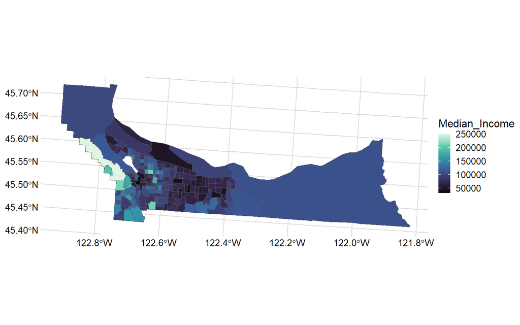

Figure 24: Median income in Multnomah County.

## `ggplot2`

```r
mult_wide |>
  ggplot() +
  geom_sf(aes(fill = Perc_College_Ed)) +
  scale_y_continuous() +
  scale_fill_viridis_c(option = "mako") +
  theme_minimal_grid(12)
```

## `ggplot2`

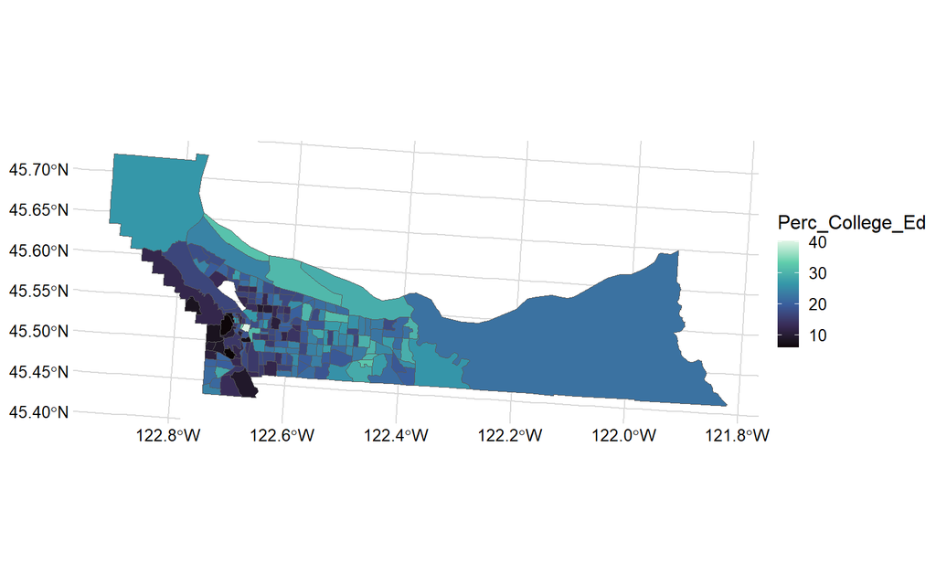

Figure 25: Percent college degree in Multnomah County.

## Your Turn

Visualize the counties in your state after an appropriate projection. You can access county data for your state (for us, Oregon) by running

```r
your_state <- "Oregon"
counties <- tigris::counties("Oregon", cb = TRUE)
```

`04:00`

## Our Turn

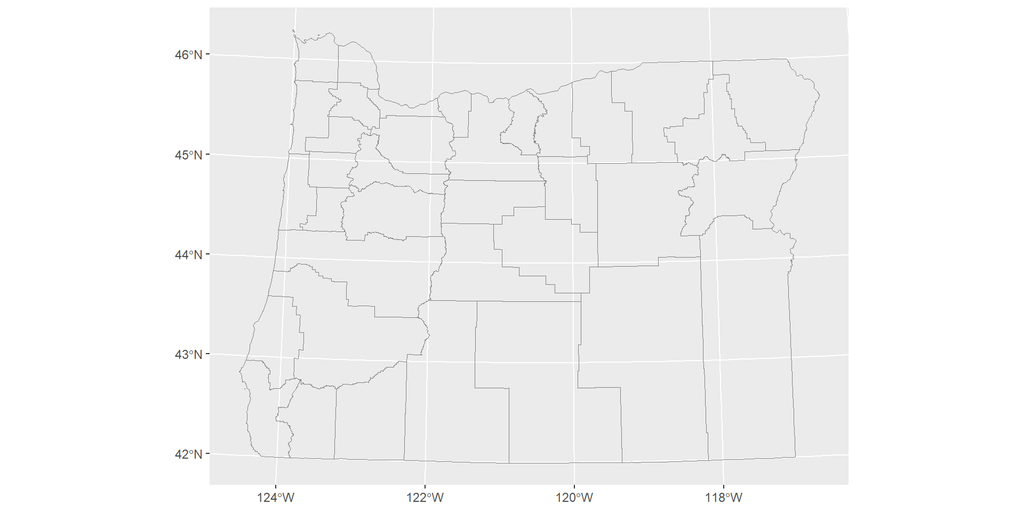

Figure 26: Oregon Counties.

```r
counties |>
  st_transform(2991) |>
  ggplot() +
  geom_sf(data = counties, fill = NA, color = gray(.5))
```

## `leaflet`

Javascript based

```r
library(leaflet)
content <- paste(sep = "<br/>",
  "<b><a href='https://www.epa.gov/greeningepa/pacific-ecological-systems-division-pesd-laboratory'>EPA Lab Corvallis</a></b>",
  "200 S.W. 35th Street ",
  "Corvallis, OR 97333 "
)

leaflet()  |>
  addTiles()  |>
  addPopups(-123.290391, 44.565548,  content,
    options = popupOptions(closeButton = FALSE)
  )
```

## `leaflet`

[figure not shown]

Figure 27: Corvallis EPA Lab.

## Your Turn

Explore some additional `leaflet` features at https://rstudio.github.io/leaflet/. Does anything seem particularly useful for your workflow?

`03:00`

## `mapview`

```r
AOI::aoi_get(list("Corvallis, OR", 10, 10)) |>
  mapview()
```

## `mapview`

Uses leaflet

[figure not shown]

Figure 28: Corvallis bounding box.

## `tmap`

Uses `ggplot2`-inspired syntax and is specifically designed for visualizing spatial data

```r
# Add fill and border layers to Oregon counties
tm_shape(counties) +
  tm_fill() +
  tm_borders()
```

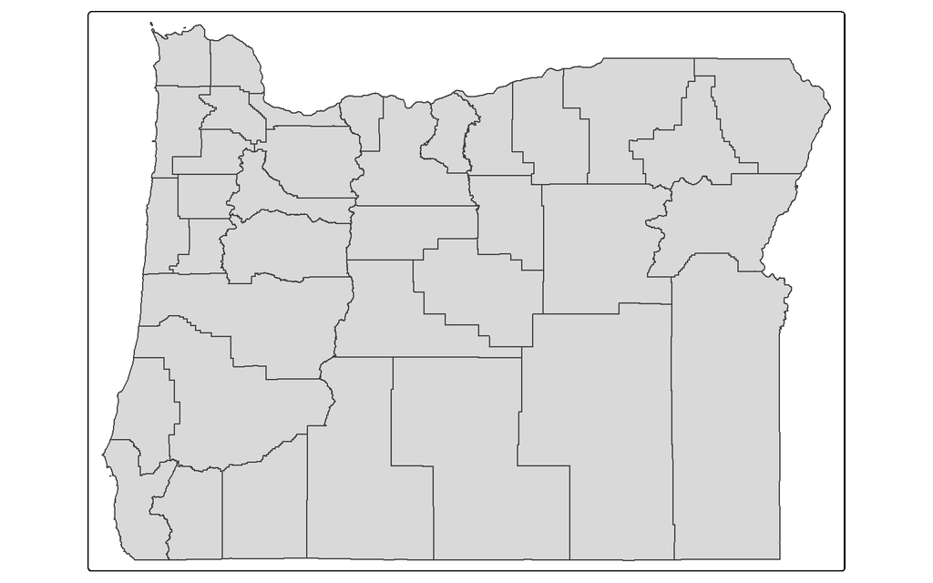

Figure 29: Oregon counties.

## `tmap`

```r
# Add fill and border layers to Oregon counties
tm_shape(mult_wide) +
  tm_polygons("Median_Income")
```

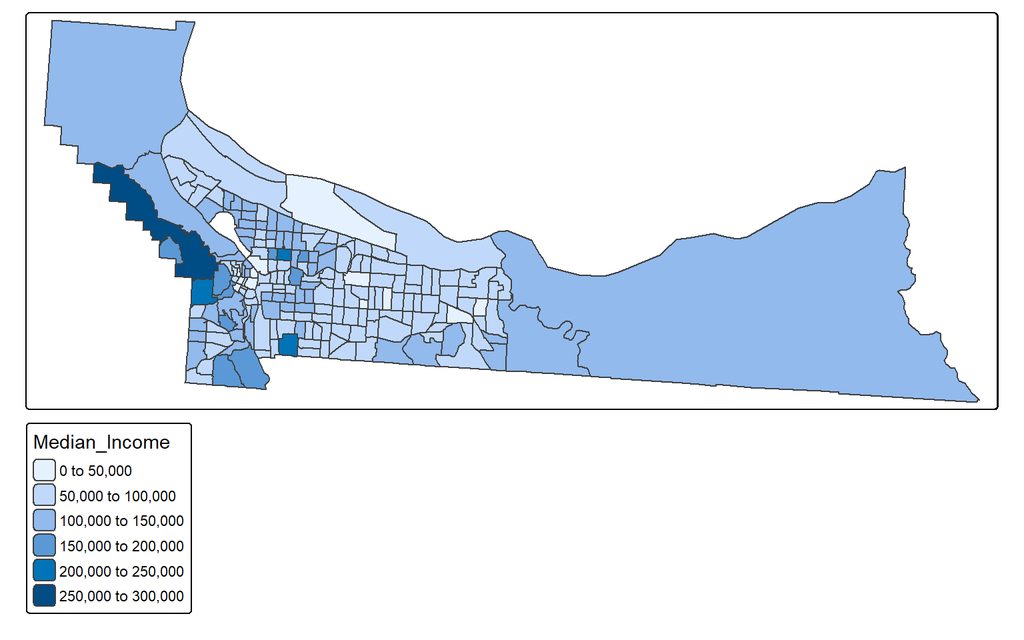

Figure 30: Median income in Multnomah County.

## Your Turn

Use `tmap` to visualize the percentage of residents with a college degree. Change the number of breaks using `n` and the color palette using `palette`.

`03:00`

## Our Turn

```r
# Add fill and border layers to Oregon counties
tm_shape(mult_wide) +
  tm_polygons("Perc_College_Ed", n = 2, palette = "BuGn")
```

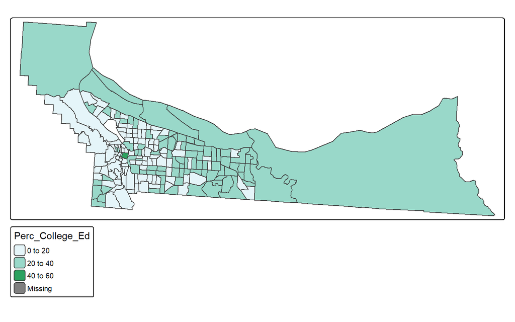

Figure 31: Percent college degree in Multnomah County.

## Your Turn

Use `tmap` to visualize the median income and the percentage of residents with a college degree using a two-column facet.

`03:00`